# Tarea Visualización de datos espaciales

*Carolina Giménez Arias*

*1. Descarga y acondiciona los datos de población de las tres provincias de la Comunidad Valenciana, por municipios, de la página web del Instituto Nacional de Estadística Padrón municipal así obtendrás los valores del padrón municipal durante los últimos años (2 puntos).*

```r
library(readxl)
library(tidyverse)
library(lettercase)
library(tmap)
library(raster)
library(shinyWidgets)
```

```r
# Cargamos los datasets descargados:
Alicante <- read_excel("./2856.xls")
```

```
-
/
```

```
* … and 64 more
```

```r
Valencia <- read_excel("./2903.xls")
```

```
-
/
```

```
* … and 64 more
```

```r
Castellon <- read_excel("./2865.xls")
```

```
-
/
```

```
* … and 64 more
```

```r
a <- c()
i = 1
for (prov in c("Castellon", "Valencia", "Alicante")){
  prov <- get(prov)
  totales <- which(grepl("Hombres",prov)==TRUE)
  prov <- prov[,1:totales-1]
  colnames(prov) <- prov[which(prov[,2] == "Total")+1,]
  colnames(prov)[1] <- "Municipio"
  split <- as.data.frame(str_split_fixed(prov$Municipio, " ",2))
  colnames(split) <- c("Codigo postal","Municipio")
  prov <- cbind(split,prov[-1])
  a[[i]] <- prov[as.numeric(which(prov$"2018" == "Total")+3):as.numeric(which(prov == "Notas:")-3),]
  i = i+1
}
Castellon <- a[[1]]
Valencia <- a[[2]]
Alicante <- a[[3]]
PoblacionCV <- rbind(Castellon, Valencia)
PoblacionCV <- rbind(PoblacionCV,Alicante)
sincod <- PoblacionCV[,2:length(PoblacionCV)] #Quitamos codigo postal
sincod <- sincod[,-which(colnames(sincod)=="1997")] # Quitamos el año 1997 ya que no contiene valores
numericosincods <- as.data.frame(sapply(sincod[,2:length(sincod)], as.numeric))
numericosincods <- cbind(Municipios=sincod[,1],numericosincods)
```

*Descarga un mapa de la Comunidad Valenciana por municipios y añade la información descargada del padrón municipal. (2 puntos )*

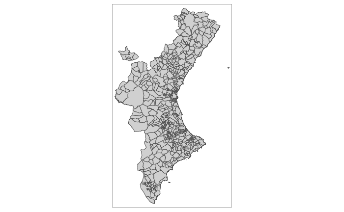

```r
SpainRegions <- getData('GADM', country='ESP', level=4)
CVRegions <- SpainRegions[which(SpainRegions$NAME_1=="Comunidad Valenciana"),]
qtm(CVRegions) #+ tm_layout("Comunidad Valenciana",legend.position = c("left","top"))
```

*Visualiza un mapa de la Comunidad que muestre la evolución de la población, por municipios. Dibuja un mapa por año (2 puntos )*

Para facilitar esta tarea, ya que tenemos el principal inconveniente de que tenemos nombres de municipios tanto en castellano como en valenciano, he descargado de wikipedia las tablas de los municipios de Valencia, Castellón y Alicante, donde aparecen las traducciones de todos los municipios. (La columna VAR_NAME4 de CVRegions contiene las traducciones de algunos municipios, sin embargo, estas no siempre se corresponderán con las “oficiales” y no concordarán con los datos descargados del INE, razón por la cual he recurrido a los ficheros de wikipedia)

```r
wikivalencia <- read_excel("./wikiValencia.xlsx")
```

```
-
/
```

```r
wikicastellon <- read_excel("./wikiCastellon.xlsx")
```

```
-
/
```

```r
wikialicante <- read_excel("./wikiAlicante.xlsx")
```

```
-
/
```

```r
#Eliminamos las ultimas columnas de cada dataset porque no nos interesarán en este problema:
wikivalencia <- wikivalencia[,1:3]
wikicastellon <- wikicastellon[,1:3]
wikialicante <- wikialicante[,1:2]
colnames(wikivalencia) <- c("Español","Valenciano","Oficial")
colnames(wikicastellon) <- c("Español","Valenciano","Oficial")
colnames(wikialicante) <- c("Español","Valenciano")
```

Fuente: https://es.wikipedia.org/wiki/Anexo:Municipios_de_la_provincia_de_Valencia Fuente: https://es.wikipedia.org/wiki/Anexo:Municipios_de_la_provincia_de_Castell%C3%B3n Fuente: https://es.wikipedia.org/wiki/Anexo:Municipios_de_la_provincia_de_Alicante

Arreglamos el desorden de letras:

```r
A <- str_split_fixed(sincod$Municipio, "/",2) #separamos palabras con "/"
A2 <- str_split_fixed(A[,1], ",",2) # separamos palabras con ","
A2[,2] <- str_replace_all(A2[,2], fixed(" "), "") %>%str_to_title()
cambio <- paste(str_to_title(A2[,2]), A2[,1], sep=" ") #unimos en el orden correcto
numericosincods$Municipio <- trimws(cambio) #quitamos espacios
MunicipiosINE <- numericosincods$Municipio
MunicipiosINE[which(startsWith(MunicipiosINE,"L\'"))] <- str_replace_all(MunicipiosINE[which(startsWith(MunicipiosINE, "L\'"))], fixed("L' "), "L'") #quito doble espacios en L'
```

Ahora hacemos uso de los datasets descargados de wikipedia para buscar coincidencias y traducir:

```r
desconocidos <- setdiff(MunicipiosINE, CVRegions$NAME_4) #municipios que estan en el documento del INE pero NO en el de mapas
matches.val <- desconocidos[desconocidos %in% wikivalencia$Valenciano]
matches.cast <- desconocidos[desconocidos %in% wikicastellon$Valenciano]
matches.ali <- desconocidos[desconocidos %in% wikialicante$Valenciano]
# Ahora sustituimos los matches por su traduccion en español:
matches.val.es <- c()
matches.cast.es <- c()
matches.ali.es <- c()
for (i in 1:length(matches.val)){
 matches.val.es[i] <- wikivalencia$Español[which(wikivalencia$Valenciano==matches.val[i])]
 MunicipiosINE[which(MunicipiosINE==matches.val[i])] <- matches.val.es[i] #Sustituimos las traducciones
}
for (i in 1:length(matches.cast)){
 matches.cast.es[i] <- wikicastellon$Español[which(wikicastellon$Valenciano==matches.cast[i])]
 MunicipiosINE[which(MunicipiosINE==matches.cast[i])] <- matches.cast.es[i] #Sustituimos las traducciones
}
for (i in 1:length(matches.ali)){
 matches.ali.es[i] <- wikialicante$Español[which(wikialicante$Valenciano==matches.ali[i])]
 MunicipiosINE[which(MunicipiosINE==matches.ali[i])] <- matches.ali.es[i] #Sustituimos las traducciones
}
# Busco a mano aquellos que no ha podido detectar el algoritmo y los corrijo:
MunicipiosINE[which(MunicipiosINE=="El Puig")] <- "Puig"
MunicipiosINE[which(MunicipiosINE=="Montitxelvo")] <- "Montichelvo"
MunicipiosINE[which(MunicipiosINE=="El Real de Gandía")] <- "Real de Gandía"
MunicipiosINE[which(MunicipiosINE=="Alfara de la Baronía")] <- "Alfara de Algimia"
MunicipiosINE[which(MunicipiosINE=="Serratella")] <- "Sarratella"
MunicipiosINE[which(MunicipiosINE == "Callosa de Ensarriá")] <- "Callosa d'En Sarrià"
MunicipiosINE[which(MunicipiosINE == "La Vall d'Ebo")] <- "Vall de Ebo"
MunicipiosINE[which(MunicipiosINE == "Les Alqueries")] <- "Alquerías del Niño Perdido"
MunicipiosINE[which(MunicipiosINE == "Useras")] <-  "Les Useras"
MunicipiosINE[which(MunicipiosINE == "Benichembla")] <- "Binigembla"
MunicipiosINE[which(MunicipiosINE == "Real")] <- "Real de Montroi"
MunicipiosINE[which(MunicipiosINE == "Llocnou de la Corona")] <- "Lugar Nuevo de la Corona"
# Guardamos en un único dataset
MunicipiosINE <- as.data.frame(cbind(MunicipiosINE,numericosincods[,2:length(numericosincods)]))
```

A continuación se comprueban como las traducciones se han hecho correctamente (están todos los municipios y no hay diferencias entre nombres del documento del Instituto Nacional de Estadística y el mapa descargado):

```r
# Buscamos coincidencias en ambos sentidos (se podria hacer con la librería operaciones join dplyr )
all((MunicipiosINE$MunicipiosINE %in% CVRegions$NAME_4))
```

```
[1] TRUE
```

```r
MunicipiosINE$MunicipiosINE[which(!(MunicipiosINE$MunicipiosINE %in% CVRegions$NAME_4))]
```

```
factor(0)
542 Levels: Ademuz Ador Adsubia Agost Agres Agullent Aielo de Malferit Aielo de Rugat Aigües Aín Alaquàs Albaida Albal ... Zucaina
```

```r
# Coincidencida en el otro sentido
all((CVRegions$NAME_4 %in% MunicipiosINE$MunicipiosINE))
```

```
[1] TRUE
```

```r
# Comprobamos que estén todos los municipios:
setdiff(MunicipiosINE$MunicipiosINE,CVRegions$NAME_4)
```

```
character(0)
```

```r
setdiff(CVRegions$NAME_4,MunicipiosINE$MunicipiosINE)
```

```
character(0)
```

Unimos y representamos el año 2018 (por ejemplo):

```r
# Unimos:
CVPoblacion <-sp::merge(CVRegions, MunicipiosINE, by.x="NAME_4", by.y="MunicipiosINE")
# Representamos:
tmap_mode("plot")
```

```
tmap mode set to plotting
```

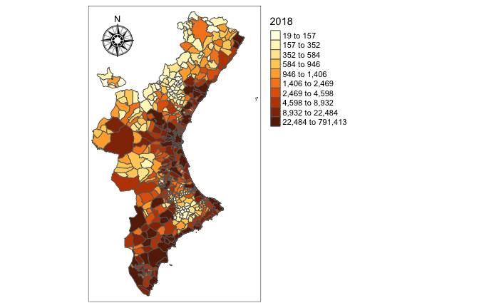

```r
tm_shape(CVPoblacion) + tm_fill("2018", style = "quantile", n = 10) +  tm_polygons() + tm_compass(type = "rose", position = c("left", "top"), size = 3) + tm_layout(legend.outside=TRUE)
```

```r
Pob.shiny <- CVPoblacion #guardamos para luego usarlo
```

```r
tmap_mode("plot")
```

```
tmap mode set to plotting
```